# Concrete

## 3. RESISTENCIA VS CENIZAS——————-

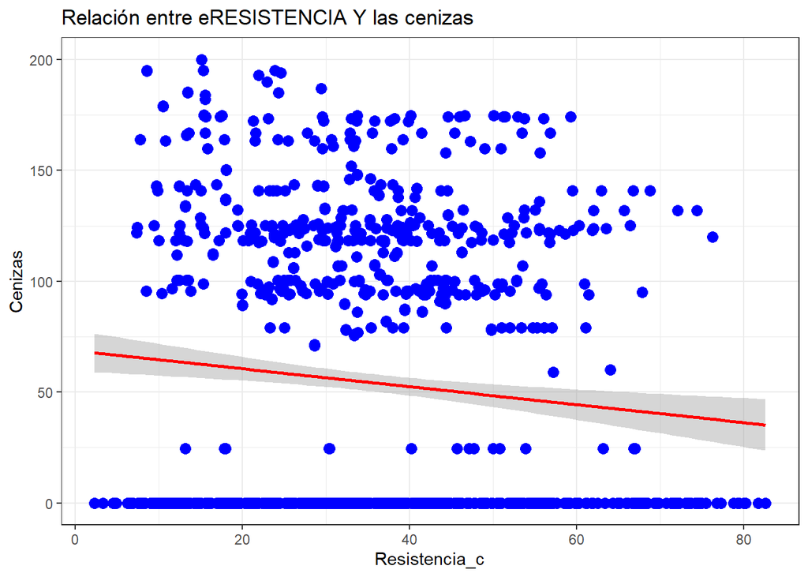

```r
df %>%
  ggplot(aes(x=Resistencia_c, y = Cenizas)) +
  geom_point(color = "blue",size = 3) +
  geom_smooth(formula = 'y~x', method = "lm",se = TRUE,color="red") +
  labs(
    title = "Relación entre eRESISTENCIA Y las cenizas",
    x = "Resistencia_c",
    y = "Cenizas"
  ) +
  theme_bw()
```

```r
ks.test(df$Cenizas, "pnorm", mean = mean(df$Cenizas), sd = sd(df$Cenizas))
```

```
##
##  Asymptotic one-sample Kolmogorov-Smirnov test
##
## data:  df$Cenizas
## D = 0.35094, p-value < 2.2e-16
## alternative hypothesis: two-sided
```

```r
#no hay normalidad, hacemos spearman, verificando supuestos

# 1️⃣ Verifica que las variables sean numéricas
is.numeric(df$Cenizas)
```

```
## [1] TRUE
```

```r
is.numeric(df$Resistencia_c)
```

```
## [1] TRUE
```

```r
# 2️⃣ Revisa valores faltantes
sum(is.na(df$Cenizas))
```

```
## [1] 0
```

```r
sum(is.na(df$Resistencia_c))
```

```
## [1] 0
```

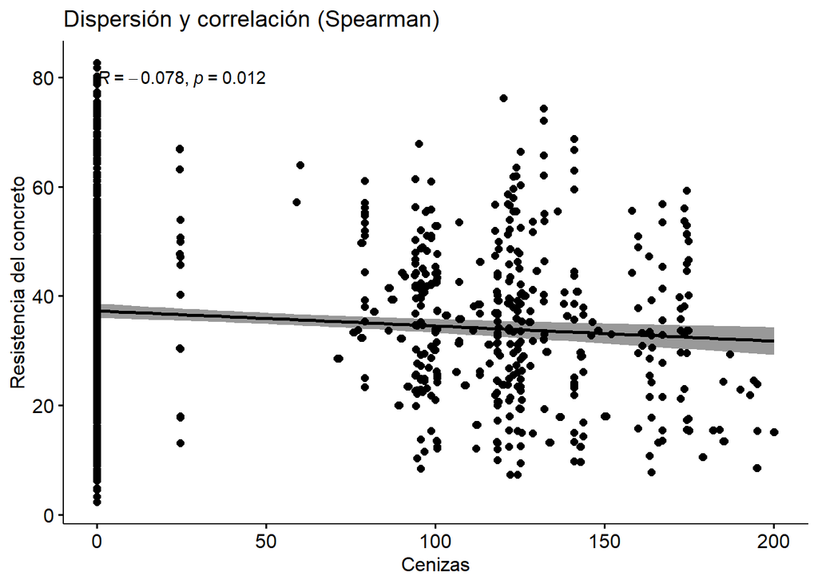

```r
# 3️⃣ Visualiza la relación
ggscatter(df, x = "Cenizas", y = "Resistencia_c",
          add = "reg.line", conf.int = TRUE,
          cor.coef = TRUE, cor.method = "spearman",
          xlab = "Cenizas", ylab = "Resistencia del concreto",
          title = "Dispersión y correlación (Spearman)")
```

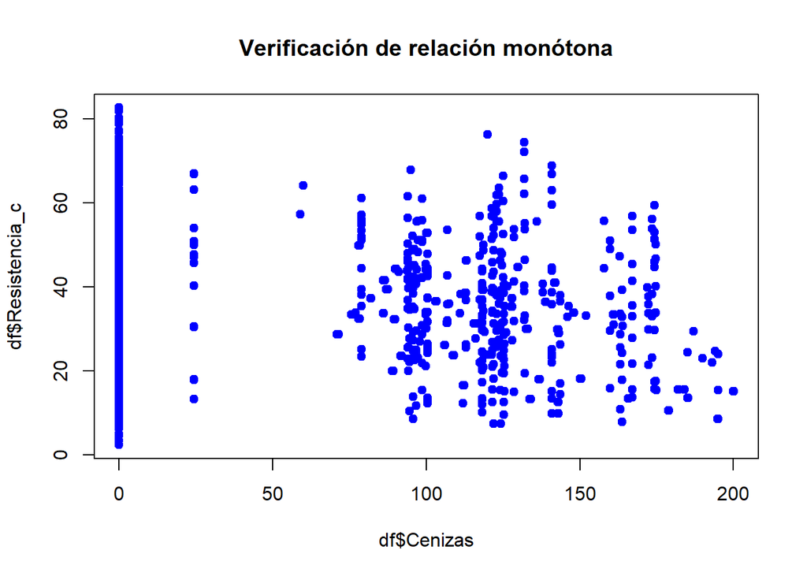

```r
# 4️⃣ Verifica la forma de la relación (monótona)
# Si la relación es creciente o decreciente, aunque no lineal, se puede usar Spearman
plot(df$Cenizas, df$Resistencia_c, pch = 19, col = "blue",
     main = "Verificación de relación monótona")
```

```r
# 5️⃣ Ejecuta la prueba de correlación de Spearman
resultado <-cor.test(df$Cenizas, df$Resistencia_c, method = "spearman", exact=FALSE)
resultado
```

```
##
##  Spearman's rank correlation rho
##
## data:  df$Cenizas and df$Resistencia_c
## S = 196318556, p-value = 0.01233
## alternative hypothesis: true rho is not equal to 0
## sample estimates:
##         rho
## -0.07795675
```

Planteamos las hipótesis:

$$H_0: \rho_S = 0 \quad \text{(no hay relación monótona)}$$

$$H_1: \rho_S \neq 0 \quad \text{(existe relación monótona)}$$

Veamos:

```r
n <- nrow(df)
gl = n-2
p = resultado$estimate[[1]]
t_critico = p*sqrt(gl/1-p^2)
alpha = 0.05
t_tab = qt(1-alpha/2,df=gl)
abs(t_critico)
```

```
## [1] 2.499476
```

```r
t_tab
```

```
## [1] 1.962274
```

rechazamos h0 :nuestro t critico mayor que el t en tabla por lo que con una confianza del 95% la correlacion es significativa

## 4. RESISTENCIA VS AGUA————

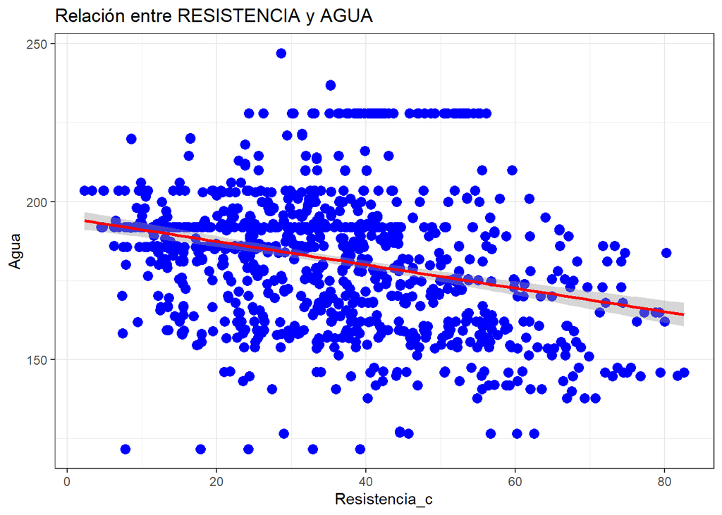

```r
df %>%
  ggplot(aes(x=Resistencia_c, y = Agua)) +
  geom_point(color = "blue",size = 3) +
  geom_smooth(formula = 'y~x', method = "lm",se = TRUE,color="red") +
  labs(
    title = "Relación entre RESISTENCIA y AGUA",
    x = "Resistencia_c",
    y = "Agua"
  ) +
  theme_bw()
```

```r
ks.test(df$Agua, "pnorm", mean = mean(df$Agua), sd = sd(df$Agua))
```

```
##
##  Asymptotic one-sample Kolmogorov-Smirnov test
##
## data:  df$Agua
## D = 0.073577, p-value = 2.869e-05
## alternative hypothesis: two-sided
```

```r
#no hay normalidad, hacemos spearman, verificando supuestos

# 1️⃣ Verifica que las variables sean numéricas
is.numeric(df$Agua)
```

```
## [1] TRUE
```

```r
is.numeric(df$Resistencia_c)
```

```
## [1] TRUE
```

```r
# 2️⃣ Revisa valores faltantes
sum(is.na(df$Agua))
```

```
## [1] 0
```

```r
sum(is.na(df$Resistencia_c))
```

```
## [1] 0
```

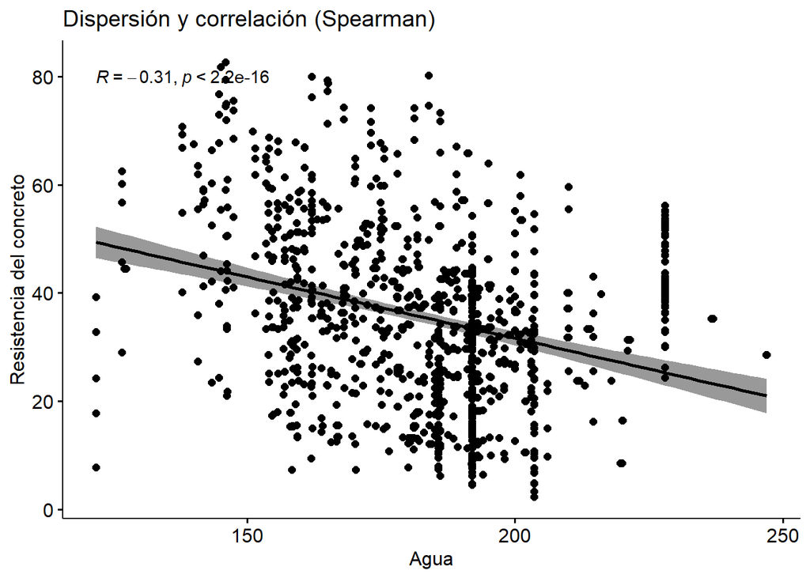

```r
# 3️⃣ Visualiza la relación
ggscatter(df, x = "Agua", y = "Resistencia_c",
          add = "reg.line", conf.int = TRUE,
          cor.coef = TRUE, cor.method = "spearman",
          xlab = "Agua", ylab = "Resistencia del concreto",
          title = "Dispersión y correlación (Spearman)")
```

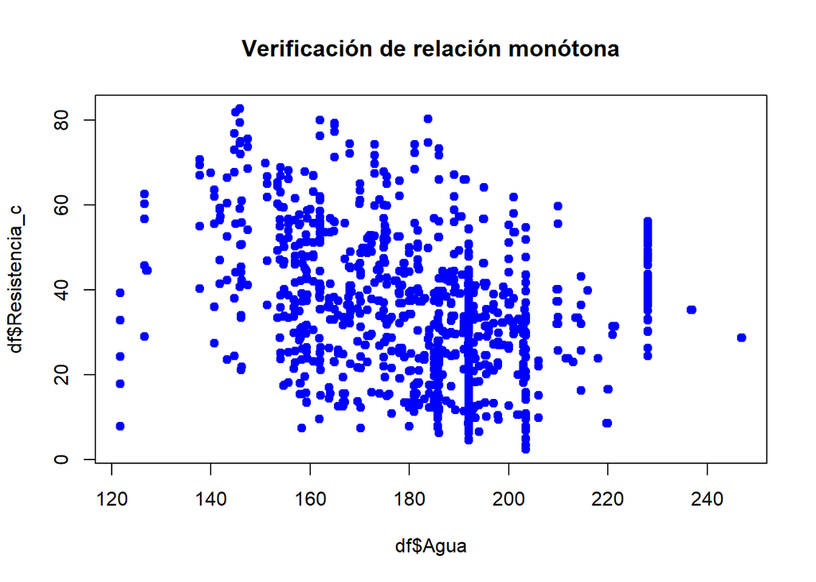

```r
# 4️⃣ Verifica la forma de la relación (monótona)
# Si la relación es creciente o decreciente, aunque no lineal, se puede usar Spearman
plot(df$Agua, df$Resistencia_c, pch = 19, col = "blue",
     main = "Verificación de relación monótona")
```

```r
# 5️⃣ Ejecuta la prueba de correlación de Spearman
resultado <- cor.test(df$Agua, df$Resistencia_c, method = "spearman", exact=FALSE)
resultado
```

```
##
##  Spearman's rank correlation rho
##
## data:  df$Agua and df$Resistencia_c
## S = 238281768, p-value < 2.2e-16
## alternative hypothesis: true rho is not equal to 0
## sample estimates:
##        rho
## -0.3083707
```

Planteamos las hipótesis:

$$H_0: \rho_S = 0 \quad \text{(no hay relación monótona)}$$

$$H_1: \rho_S \neq 0 \quad \text{(existe relación monótona)}$$

Veamos:

```r
n <- nrow(df)
gl = n-2
p = resultado$estimate[[1]]
t_critico = p*sqrt(gl/1-p^2)
alpha = 0.05
t_tab = qt(1-alpha/2,df=gl)
abs(t_critico)
```

```
## [1] 9.886658
```

```r
t_tab
```

```
## [1] 1.962274
```

rechazamos h0 :nuestro t critico mayor que el t en tabla por lo que con una confianza del 95% la correlacion es significativa

## 5. RESISTENCIA VS Superplastificante———–

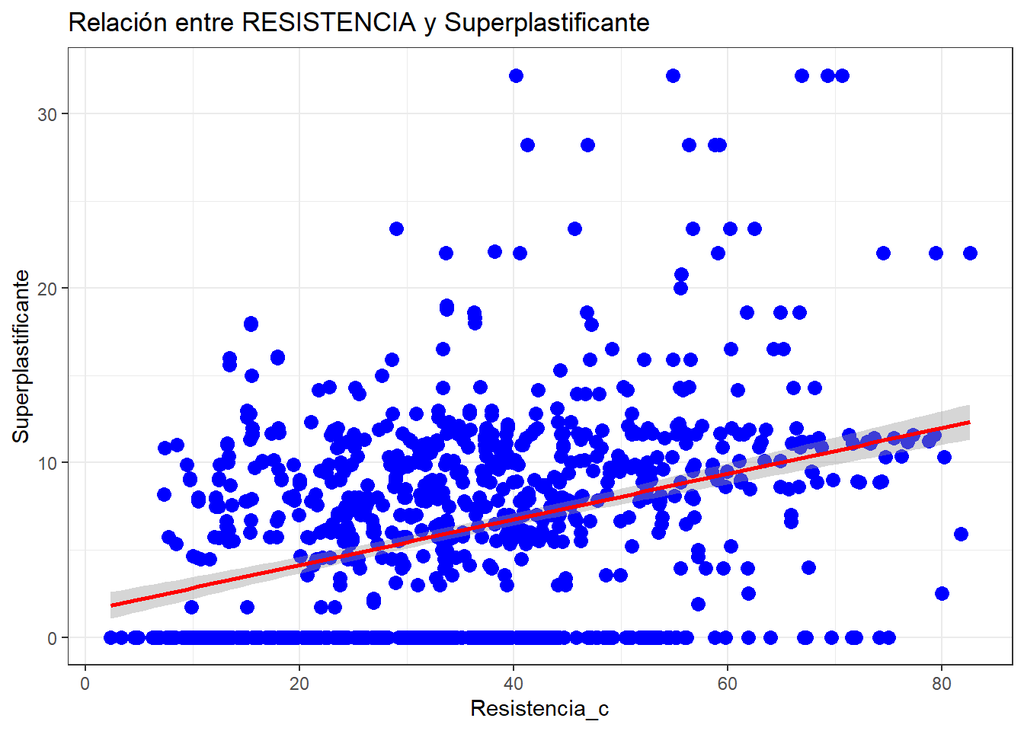

```r
df %>%
  ggplot(aes(x=Resistencia_c, y = Superplastificante)) +
  geom_point(color = "blue",size = 3) +
  geom_smooth(formula = 'y~x', method = "lm",se = TRUE,color="red") +
  labs(
    title = "Relación entre RESISTENCIA y Superplastificante",
    x = "Resistencia_c",
    y = "Superplastificante"
  ) +
  theme_bw()
```

```r
ks.test(df$Superplastificante, "pnorm", mean = mean(df$Superplastificante), sd = sd(df$Superplastificante))
```

```
##
##  Asymptotic one-sample Kolmogorov-Smirnov test
##
## data:  df$Superplastificante
## D = 0.21843, p-value < 2.2e-16
## alternative hypothesis: two-sided
```

```r
#no hay normalidad, hacemos spearman, verificando supuestos

# 1️⃣ Verifica que las variables sean numéricas
is.numeric(df$Superplastificante)
```

```
## [1] TRUE
```

```r
is.numeric(df$Resistencia_c)
```

```
## [1] TRUE
```

```r
# 2️⃣ Revisa valores faltantes
sum(is.na(df$Superplastificante))
```

```
## [1] 0
```

```r
sum(is.na(df$Resistencia_c))
```

```
## [1] 0
```

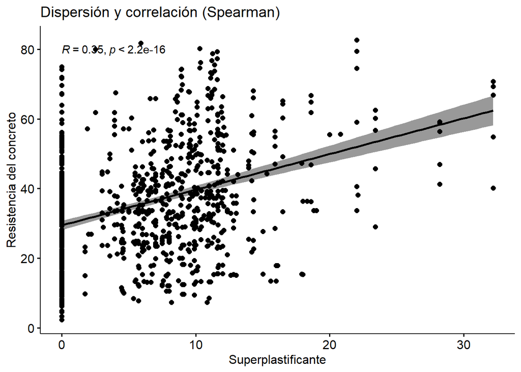

```r
# 3️⃣ Visualiza la relación
ggscatter(df, x = "Superplastificante", y = "Resistencia_c",
          add = "reg.line", conf.int = TRUE,
          cor.coef = TRUE, cor.method = "spearman",
          xlab = "Superplastificante", ylab = "Resistencia del concreto",
          title = "Dispersión y correlación (Spearman)")
```

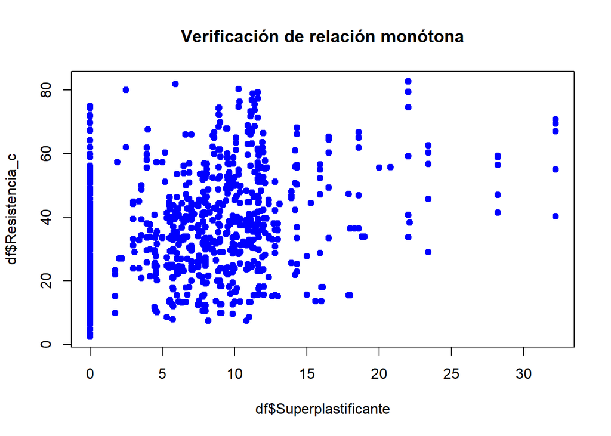

```r
# 4️⃣ Verifica la forma de la relación (monótona)
# Si la relación es creciente o decreciente, aunque no lineal, se puede usar Spearman
plot(df$Superplastificante, df$Resistencia_c, pch = 19, col = "blue",
     main = "Verificación de relación monótona")
```

```r
# 5️⃣ Ejecuta la prueba de correlación de Spearman
resultado <- cor.test(df$Superplastificante, df$Resistencia_c, method = "spearman", exact=FALSE)
resultado
```

```
##
##  Spearman's rank correlation rho
##
## data:  df$Superplastificante and df$Resistencia_c
## S = 118817755, p-value < 2.2e-16
## alternative hypothesis: true rho is not equal to 0
## sample estimates:
##       rho
## 0.3475889
```

Planteamos las hipótesis:

$$H_0: \rho_S = 0 \quad \text{(no hay relación monótona)}$$

$$H_1: \rho_S \neq 0 \quad \text{(existe relación monótona)}$$

Veamos:

```r
n <- nrow(df)
gl = n-2
p = resultado$estimate[[1]]
t_critico = p*sqrt(gl/1-p^2)
alpha = 0.05
t_tab = qt(1-alpha/2,df=gl)
t_critico
```

```
## [1] 11.14389
```

```r
t_tab
```

```
## [1] 1.962274
```

rechazamos h0 :nuestro t critico mayor que el t en tabla por lo que con una confianza del 95% la correlacion es significativa

## 6. RESISTENCIA VS Grueso————

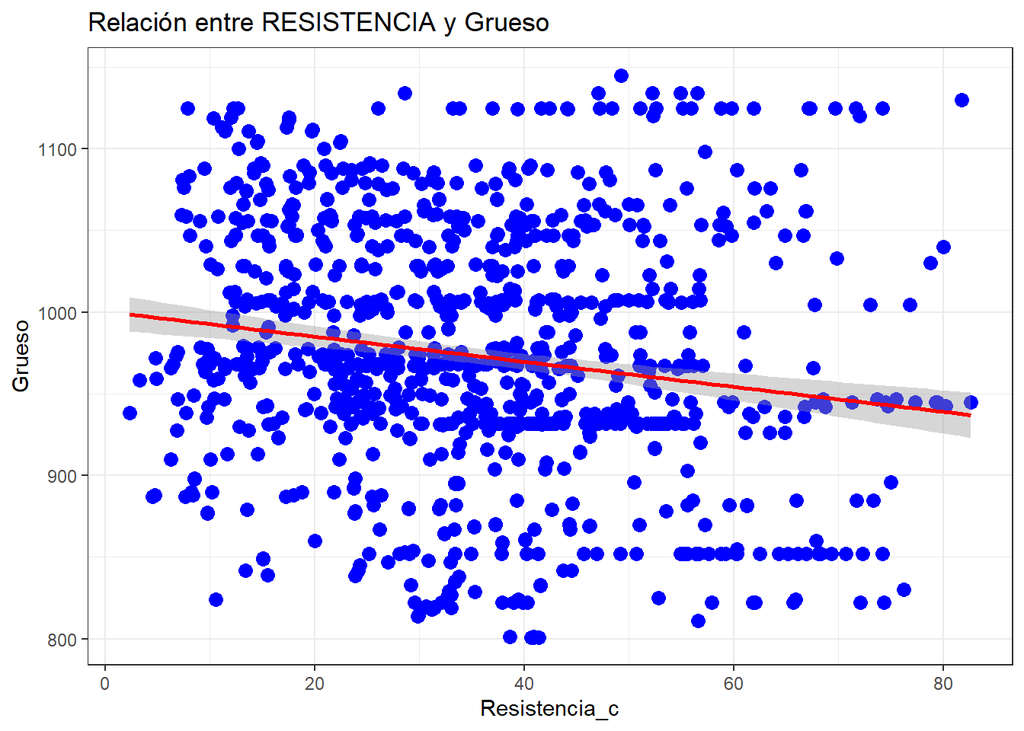

```r
df %>%
  ggplot(aes(x=Resistencia_c, y = Grueso)) +
  geom_point(color = "blue",size = 3) +
  geom_smooth(formula = 'y~x', method = "lm",se = TRUE,color="red") +
  labs(
    title = "Relación entre RESISTENCIA y Grueso",
    x = "Resistencia_c",
    y = "Grueso"
  ) +
  theme_bw()
```

```r
ks.test(df$Grueso, "pnorm", mean = mean(df$Grueso), sd = sd(df$Grueso))
```

```
##
##  Asymptotic one-sample Kolmogorov-Smirnov test
##
## data:  df$Grueso
## D = 0.063834, p-value = 0.0004524
## alternative hypothesis: two-sided
```

```r
# 1️⃣ Verifica que las variables sean numéricas
is.numeric(df$Grueso)
```

```
## [1] TRUE
```

```r
is.numeric(df$Resistencia_c)
```

```
## [1] TRUE
```

```r
# 2️⃣ Revisa valores faltantes
sum(is.na(df$Grueso))
```

```
## [1] 0
```

```r
sum(is.na(df$Resistencia_c))
```

```
## [1] 0
```

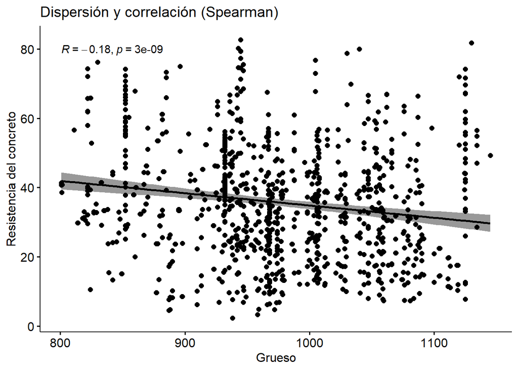

```r
# 3️⃣ Visualiza la relación
ggscatter(df, x = "Grueso", y = "Resistencia_c",
          add = "reg.line", conf.int = TRUE,
          cor.coef = TRUE, cor.method = "spearman",
          xlab = "Grueso", ylab = "Resistencia del concreto",
          title = "Dispersión y correlación (Spearman)")
```

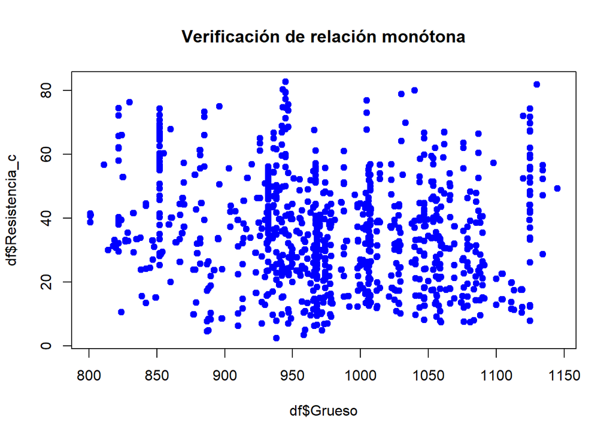

```r
# 4️⃣ Verifica la forma de la relación (monótona)
# Si la relación es creciente o decreciente, aunque no lineal, se puede usar Spearman
plot(df$Grueso, df$Resistencia_c, pch = 19, col = "blue",
     main = "Verificación de relación monótona")
```

```r
# 5️⃣ Ejecuta la prueba de correlación de Spearman
resultado <- cor.test(df$Grueso, df$Resistencia_c, method = "spearman", exact=FALSE)
resultado
```

```
##
##  Spearman's rank correlation rho
##
## data:  df$Grueso and df$Resistencia_c
## S = 215543059, p-value = 2.975e-09
## alternative hypothesis: true rho is not equal to 0
## sample estimates:
##        rho
## -0.1835157
```

Planteamos las hipótesis:

$$H_0: \rho_S = 0 \quad \text{(no hay relación monótona)}$$

$$H_1: \rho_S \neq 0 \quad \text{(existe relación monótona)}$$

Veamos:

```r
n <- nrow(df)
gl = n-2
p = resultado$estimate[[1]]
t_critico = p*sqrt(gl/1-p^2)
alpha = 0.05
t_tab = qt(1-alpha/2,df=gl)
abs(t_critico)
```

```
## [1] 5.883865
```

```r
t_tab
```

```
## [1] 1.962274
```

rechazamos h0 :nuestro t critico mayor que el t en tabla por lo que con una confianza del 95% la correlacion es significativa

## 7. RESISTENCIA VS Fino————

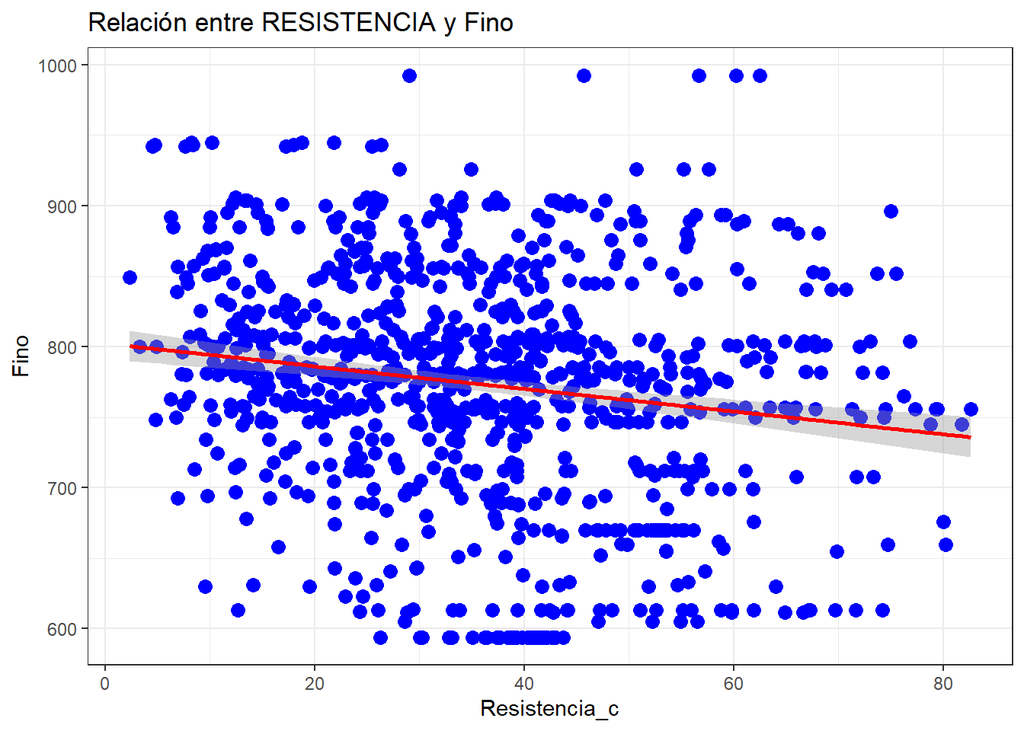

```r
df %>%
  ggplot(aes(x=Resistencia_c, y = Fino)) +
  geom_point(color = "blue",size = 3) +
  geom_smooth(formula = 'y~x', method = "lm",se = TRUE,color="red") +
  labs(
    title = "Relación entre RESISTENCIA y Fino",
    x = "Resistencia_c",
    y = "Fino"
  ) +
  theme_bw()
```

```r
ks.test(df$Fino, "pnorm", mean = mean(df$Fino), sd = sd(df$Fino))
```

```
##
##  Asymptotic one-sample Kolmogorov-Smirnov test
##
## data:  df$Fino
## D = 0.085723, p-value = 5.33e-07
## alternative hypothesis: two-sided
```

```r
# 1️⃣ Verifica que las variables sean numéricas
is.numeric(df$Fino)
```

```
## [1] TRUE
```

```r
is.numeric(df$Resistencia_c)
```

```
## [1] TRUE
```

```r
# 2️⃣ Revisa valores faltantes
sum(is.na(df$Fino))
```

```
## [1] 0
```

```r
sum(is.na(df$Resistencia_c))
```

```
## [1] 0
```

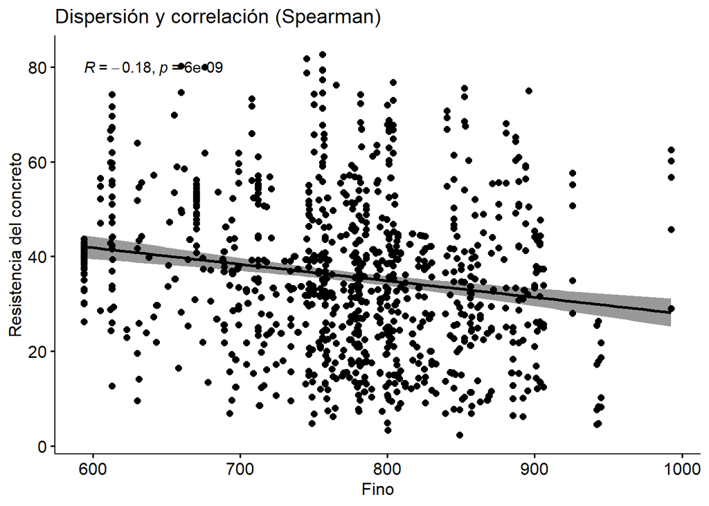

```r
# 3️⃣ Visualiza la relación
ggscatter(df, x = "Fino", y = "Resistencia_c",
          add = "reg.line", conf.int = TRUE,
          cor.coef = TRUE, cor.method = "spearman",
          xlab = "Fino", ylab = "Resistencia del concreto",
          title = "Dispersión y correlación (Spearman)")
```

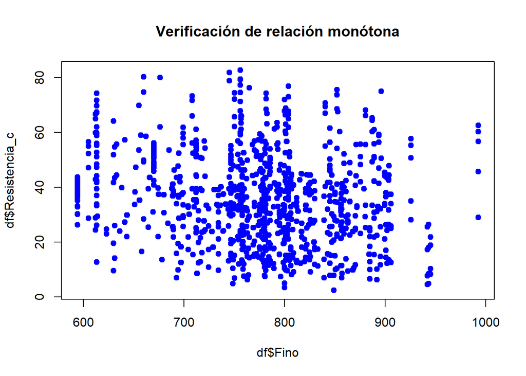

```r
# 4️⃣ Verifica la forma de la relación (monótona)
# Si la relación es creciente o decreciente, aunque no lineal, se puede usar Spearman
plot(df$Fino, df$Resistencia_c, pch = 19, col = "blue",
     main = "Verificación de relación monótona")
```

```r
# 5️⃣ Ejecuta la prueba de correlación de Spearman
resultado <- cor.test(df$Fino, df$Resistencia_c, method = "spearman", exact=FALSE)
resultado
```

```
##
##  Spearman's rank correlation rho
##
## data:  df$Fino and df$Resistencia_c
## S = 214901130, p-value = 5.987e-09
## alternative hypothesis: true rho is not equal to 0
## sample estimates:
##       rho
## -0.179991
```

Planteamos las hipótesis:

$$H_0: \rho_S = 0 \quad \text{(no hay relación monótona)}$$

$$H_1: \rho_S \neq 0 \quad \text{(existe relación monótona)}$$

Veamos:

```r
n <- nrow(df)
gl = n-2
p = resultado$estimate[[1]]
t_critico = p*sqrt(gl/1-p^2)
alpha = 0.05
t_tab = qt(1-alpha/2,df=gl)
abs(t_critico)
```

```
## [1] 5.770859
```

```r
t_tab
```

```
## [1] 1.962274
```

rechazamos h0 :nuestro t critico mayor que el t en tabla por lo que con una confianza del 95% la correlacion es significativa